# Hypothesis Testing for Linear Regression

Applied Statistics

MTH-361A | Spring 2025 | University of Portland

April 11, 2025

# Objectives

- **Develop an understanding of hypothesis testing for linear regression**
- **Know the procedural steps for inference for linear regression**
- **Know how to conclude the hypothesis test for linear regression**
- **Activity: Conduct a Hypothesis Test for Linear Regression**

# Previously…

**Linear Regression**

$$y = \beta_0 + \beta_1 x +
\epsilon$$

- $y$ is the outcome, $x$ is the predictor, $\beta_0$ is the intercept, and $\beta_1$ is the slope. The notation $\epsilon$ is the model’s error (residuals).
- We estimate the slope $b_1$ and intercept $b_0$ of the least squares regression line by minimizing the sum of squared residuals.
- The slope is given by $b_1 = \frac{s_y}{s_x} r$ , and the intercept is $b_0 = \bar{y} - b_1 \bar{x}$ , where $r$ is the correlation coefficient, $s_x$ and $s_y$ are the standard deviations of $x$ and $y$, and $\bar{x}$, $\bar{y}$ are their respective means.

# Case Study I

Consider data births gathered originally from the US Department of Health and Human Services. The [`births14`](http://openintrostat.github.io/openintro/reference/births14.html) data can be found in the [**openintro**](http://openintrostat.github.io/openintro) R package.

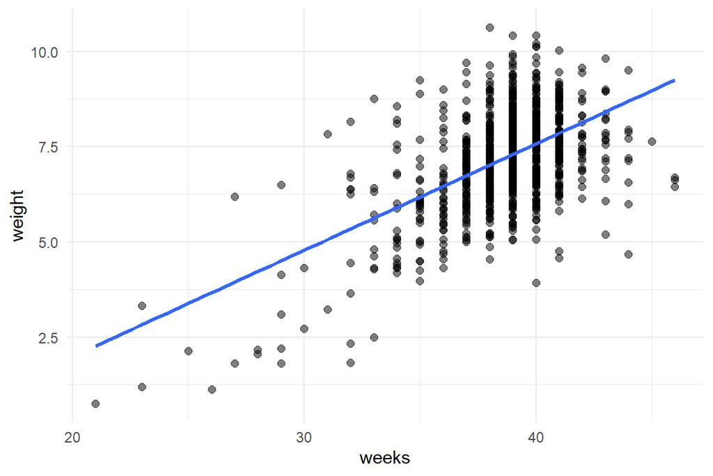

# Case Study I: The Linear Model

We want to predict the baby weight based on number of weeks. The population linear model is
$$y_{weight} =
\beta_0 + \beta_1 x_{weeks} + e$$

The relevant hypotheses for the linear model setting can be written in terms of the population slope parameter.

Here the population refers to a larger population of births in the US.

- $H_0: \beta_1= 0$, there is no linear relationship between `weight` and `weeks`.
- $H_A: \beta_1 \ne 0$, there is some linear relationship between `weight` and `weeks`.

Let’s set the significance value to be $\alpha = 0.01$.

# Technical Conditions

- **Linearity.** The scatterplot of the explanatory and response must be nearly linear.
- **Independent Observations.** The samples must be independent.
- **Normally Distributed Residuals.** The errors must show a nearly normal distribution.
- **Constant or equal variability.** The error must exhibit homoscedasticity.

# Case Study 1: Residual Analysis (1/2)

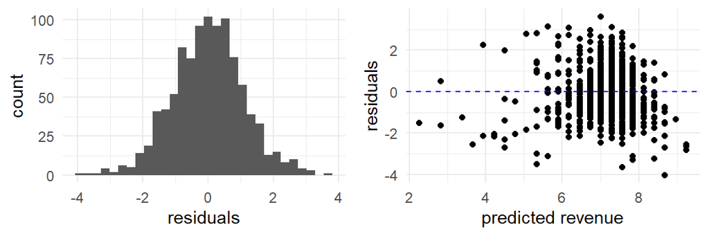

- The residuals appear approximately normal, supporting the normality assumption.
- The residual plot shows roughly “constant” variance, suggesting homoskedasticity.
- Slight clustering near the center may require further investigation but otherwise the residuals are independent of the model (no pattern).

# Case Study 1: Residual Analysis (2/2)

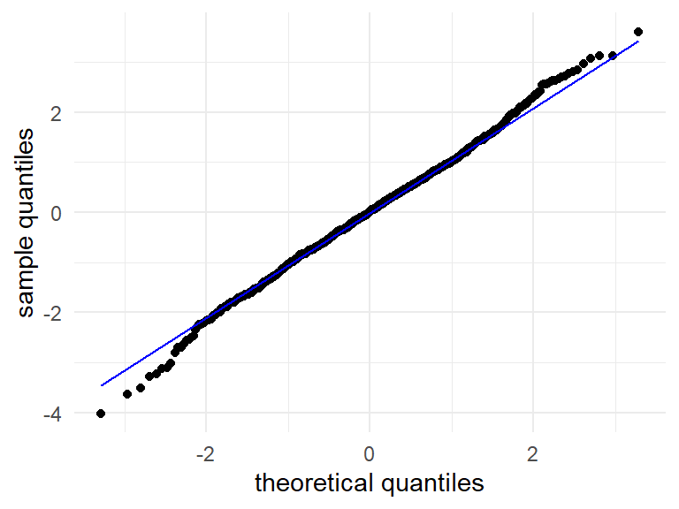

# Case Study 1: Least Squares Approximation

The least squares estimates of the intercept and slope are given in the estimate column

| term | estimate | std.error |
| --- | --- | --- |
| (Intercept) | -3.5980 | 0.5227 |
| weeks | 0.2792 | 0.0135 |

The least squares regression model uses the data to find a sample linear fit:
$$\hat{y}_{weight} = -3.5980 +
0.2792 \times x_{weeks}.$$

R code:

```r
lm(weight ~ weeks, data = births14)
```

where the data is stored as a data frame named `births14` and `weight` and `weeks` are two numerical variables in the data frame.

# Hypothesis Testing - Randomization Method (1/2)

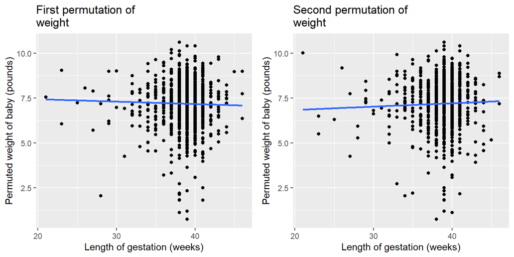

Two different permutations of the `weight` variable with slightly different least squares regression lines.

# Hypothesis Testing - Randomization Method (2/2)

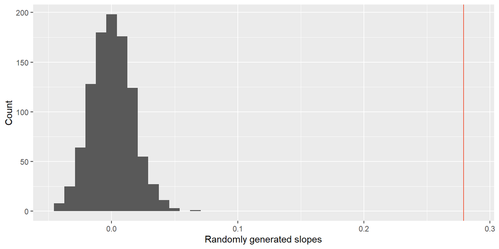

Histogram of slopes given different permutations of the `weight` variable. The vertical red line is at the observed value of the slope, 0.28.

# Hypothesis Testing - Theoretical Method

The least squares estimates of the intercept and slope are given in the estimate column

| term | estimate | std.error | statistic | p.value |
| --- | --- | --- | --- | --- |
| (Intercept) | -3.5980 | 0.5227 | -6.8831 | 0 |
| weeks | 0.2792 | 0.0135 | 20.6988 | 0 |

- Computing the test statistic.
  $$t =
  \frac{b_1 - \text{null value}}{SE} = \frac{0.2792 - 0}{0.0135} =
  20.69$$
- Degrees of Freedom: $df = n - k - 1$, where $n$ is the sample size and $k$ is the number of predictors. So, in this case, $df = 1000 - 2 = 998$.

**Using R to compute the p-value**

```r
2*(1-pt(20.69,998))
```

```
## [1] 0
```

# Confidence Interval (1/2)

**99% Confidence interval for the slope**

$$b_1 \pm t_{df}^*
\text{SE}_{b_1}$$

- Critical t-star for a 0.99 confidence level: $t_{df}^* = t_{998}^* = 2.5808$. Note that we use $1-\alpha$ as the confidence level, where $alpha = 0.01$.

**Using R to compute the critical t-star**

```r
qt((1-0.99)/2,998)
```

```
## [1] -2.580765
```

$$\begin{aligned}
0.2792 & \pm 2.5808 \times 0.0135
\end{aligned}$$
$$(0.2444,0.3140)$$

We are 99% confident that the true slope is in between 0.2444 and 0.3140. Note that the null value of 0 (no slope) is not within the interval.

# Confidence Interval (2/2)

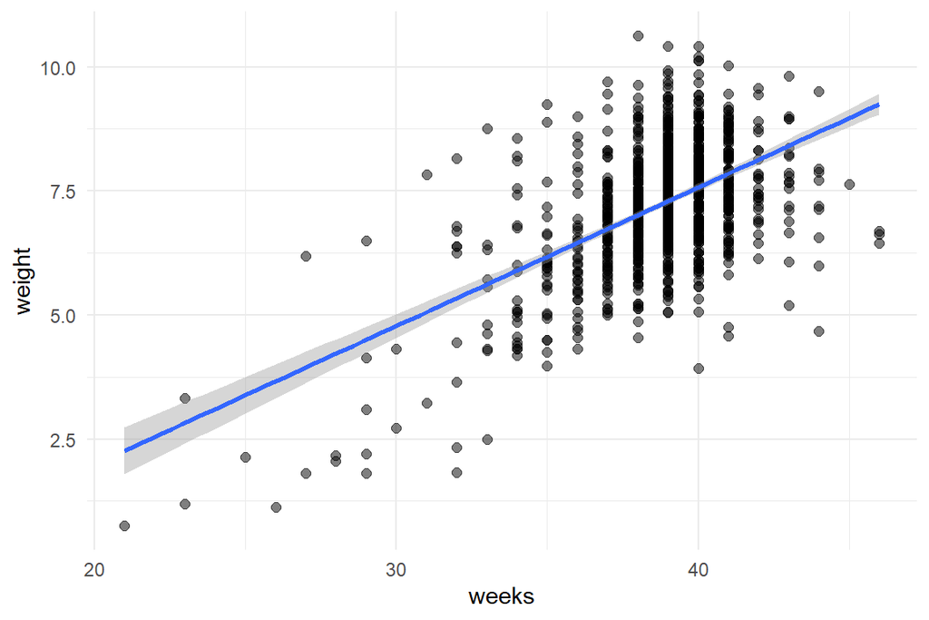

# Activity: Conduct a Hypothesis Test for Linear Regression

1. Log-in to Posit Cloud and open the R Studio assignment *F 4/11 - Conduct a Hypothesis Test for Linear Regression*.
2. Make sure you are in the current working directory. Rename the `.Rmd` file by replacing `[name]` with your name using the format `[First name][Last initial]`. Then, open the `.Rmd` file.
3. Change the author in the YAML header.
4. Read the provided instructions.
5. Answer all exercise problems on the designated sections.

# References

Diez, D. M., Barr, C. D., & Çetinkaya-Rundel, M. (2012). *OpenIntro statistics* (4th ed.). OpenIntro. https://www.openintro.org/book/os/

Speegle, Darrin and Clair, Bryan. (2021). *Probability, statistics, and data: A fresh approach using r*. Chapman; Hall/CRC. https://probstatsdata.com/